# Integration of scRNA & spatial transcriptomics using bindSC

Jinzhuang Dou @ Kenchen’lab (MDACC)

February 12, 2021

This guide will demonstrate the usage of bindSC to integrate scRNA-seq and spatial transcriptomics (ST). Here we project cells from scRNA-seq onto the spatial space. The SC data used in this evaluation can be downloaded from https://drive.google.com/file/d/1o0YOZ4yNV9d26dAcNPh2pabldrwiHCBR/view?usp=sharing. The ST data used in this evaluation can be downloaded from https://drive.google.com/file/d/1abfboNQsZEbIBmwvoVEo2ktzSv-KvrF3/view?usp=sharing.

Change the input to your own file path.

#### Stage 1: Load the scRNA-seq and ST data

```r
library(bindSC)
SC <- readRDS(file="./../../data/spatial_rna.rds")
ST <- readRDS(file="./../../data/spatial_ST.rds")
summary(SC)
```

```
##      Length   Class      Mode
## RNA  11001000 dgCMatrix  S4
## umap     9500 -none-     numeric
## meta       54 data.frame list
```

```r
summary(ST)
```

```
##      Length   Class      Mode
## RNA   2482752 dgCMatrix  S4
## umap        2 DimReduc   S4
## ST   33288816 dgCMatrix  S4
## meta        9 data.frame list
```

We then visualize each cell, colored by cell type, from two technologies. Left is UMAP from scRNA-seq, and right is from ST data. For each spot in ST data, it may include more than 10 cells. Although both modalites were measured on gene expression level, there is still feature heterogenity.

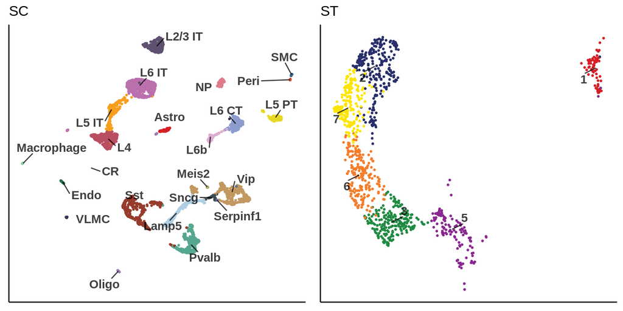

```r
tp <- data.frame("UMAP1"=SC$umap[,1], "UMAP2"=SC$umap[,2], "celltype"=SC$meta$subclass)

p11 <- UMAP_plot(meta = tp, color = "celltype",  mylabel=paletteDiscrete(tp$celltype),alpha = 1,
                 xlim=c(min(tp$UMAP1), max(tp$UMAP1)), ylim=c(min(tp$UMAP1), max(tp$UMAP2))) + ggtitle("SC")

tp <- data.frame("UMAP1"=ST$umap@cell.embeddings[,1],
                 "UMAP2"=ST$umap@cell.embeddings[,2],
                 "celltype"=ST$meta$seurat_clusters)

p12 <- UMAP_plot(meta = tp, color = "celltype", mylabel=paletteDiscrete(tp$celltype),alpha = 1,
                 xlim=c(min(tp$UMAP1), max(tp$UMAP1)), ylim=c(min(tp$UMAP2), max(tp$UMAP2))) + ggtitle("ST")

p1 <- ggarrange(p11, p12,  ncol=2, nrow=1)
p1
```

Prepare for the input for bindSC alignment. Here we set Z0 = Y. Here we use low-dimension representations rather than the orignal matrixs for bindSC alignment. You should perform dimension reductions (SVD) on `X` and `Z0` jointly.

```r
x.clst <- SC$meta$subclass
y.clst <- ST$meta$seurat_clusters

out <- dimReduce( dt1 =  SC$RNA, dt2 = ST$RNA,  K = 30)
x <- out$dt1
z0 <- out$dt2
y <- ST$RNA
```

#### Stage 3: Parameter optimization [optional]

There are two key parameters that may influence the integraton results: 1) `lambda` the modality weighting factor; 2) `alpha` the weighting factor of initilized gene score matrix. The `parameter optimization` step will run bindS alignment with `0<lambda<1` and `0<alpha<1`. This may take a long time if the sampe size is large. We found the defualt settings with lambda = 0.5 and alpha = 0.5 work well on most integration tasks. The `parameter optimization` step could be skipped if you want to use the default settings.

To run the `parameter optimization` step, you need to prepare for the cluster annotaions for each dataset. I will skip this step and use default parameters in bindSC.

```r
run = FALSE
if(run){
  paraSel <- BiCCA_para_opt( X = t(x) ,
               Y = y,
               Z0 =t(z0),
               tp="out",
               X.clst = x.clst,
               Y.clst = y.clst,
               alpha.lst = seq(0,1,0.1),
               K.lst = c(15),
               lambda.lst = seq(0,1,0.1),
               num.iteration = 50,
               tolerance = 0.01,
               save = TRUE,
               block.size = 1000
  )
  p1 <- paraSel_plot(paraSel)
  p1

  tiff("paraSel.tiff", width=12, height =3, res =300, units = "in")
  print(p1)
  dev.off()
}
```

#### Stage 4: Run bindSC

```r
res <- BiCCA( X = t(x) ,
             Y = y,
             Z0 = t(z0) ,
             X.clst = x.clst,
             Y.clst = y.clst,
             alpha = 0.5,
             lambda = 0.5,
             K = 15,
             temp.path  = "out",
             num.iteration = 50,
             tolerance = 0.01,
             save = TRUE,
             parameter.optimize = FALSE,
             block.size = 0)
```

```
## 2021-06-28 14:37:03  Started!
```

```
## 2021-06-28 14:37:04  Dimension Check: X[30x4750] Y[2316x1072] Z0[30x1072]
```

```
## 2021-06-28 14:37:04  Decomposing started!
```

[output not shown]

```
## 2021-06-28 14:37:13  Done! The decomposition is converged.
```

Check the iteration process using `plotIteration` function (optional). The first row shows the objective function costs for 3 terms separately. The fourth figure shows the total objective function over iteration time. The fifth figure figure shows the relative change of gene score matrix Z over iteration time.

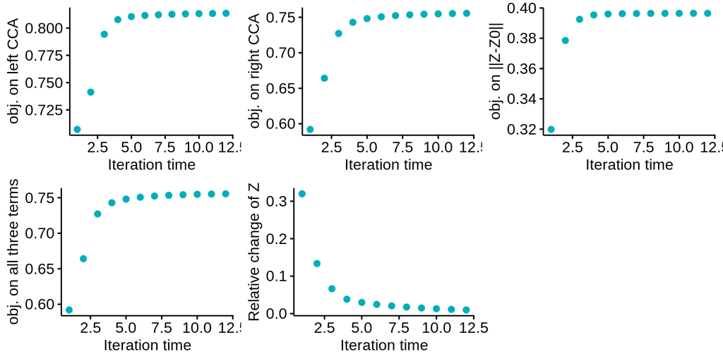

```r
p2 <- plotIteration(res)
p2
```

```r
tiff("iteration.cost.tiff", width=12, height =6, res =300, units = "in")
print(p2)
dev.off()
```

#### Stage 4: Project cells from two modalites in co-embedding spaces. `res$u` and `res$r` denote the coordinates of two modalites in co-embeddings.

[figure not shown]

```r
res <- readRDS(file="./out/out_final.rds")
dim(res$u)
dim(res$r)
umap_plt <- umap(rbind(res$u, res$r))
umap_plt  <- data.frame("UMAP1"=umap_plt$layout[,1],
                        "UMAP2"=umap_plt$layout[,2],
                        "celltype" = c(x.clst, y.clst),
                        "data" = c(rep("scRNA-seq",ncol(t(x))),
                                   rep("scATAC-seq",ncol(y))))

xlim <- c(min(umap_plt$UMAP1), max(umap_plt$UMAP1))
ylim <- c(min(umap_plt$UMAP2), max(umap_plt$UMAP2))

p11 <- UMAP_plot(meta = umap_plt[umap_plt$data=="scRNA-seq",], mylabel = paletteDiscrete(umap_plt$celltype),
                 alpha=1,color = "celltype", xlim = xlim, ylim = ylim) + ggtitle("SC")
p12 <- UMAP_plot(meta = umap_plt[umap_plt$data=="scATAC-seq",], mylabel=paletteDiscrete(umap_plt$celltype),
                 alpha = 1,color = "celltype", xlim = xlim, ylim = ylim)  + ggtitle("ST")

p3 <- ggarrange(p11,p12, ncol=2)
print(p3)
```

#### Stage 5: Label transfer from scRNA-seq data to ST data.

```r
library(e1071)
library(corrplot)
cell_type_predict <- label_transfer(dt1=res$u, X.clst=x.clst, dt2=res$r)
head(cell_type_predict)
```

```
##                          celltype  Prob_max
## AAACAGAGCGACTCCT-1_query  L2/3 IT 0.9886358
## AAACCGGGTAGGTACC-1_query      Vip 0.6378843
## AAACCGTTCGTCCAGG-1_query      Vip 0.2251093
## AAACTCGTGATATAAG-1_query    L6 IT 0.1904646
## AAAGGGATGTAGCAAG-1_query      Sst 0.5169479
## AAATAACCATACGGGA-1_query      Vip 0.9282774
```

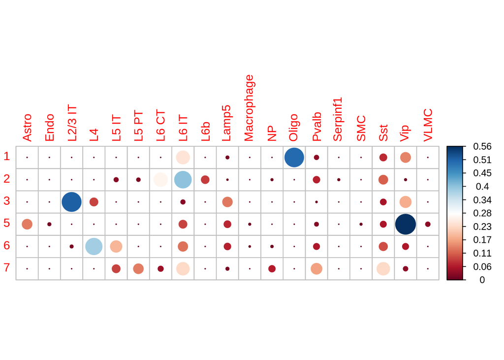

```r
cell_type_predict$cluster<-as.character(y.clst)

confus_mat <- as.matrix(table(cell_type_predict[,c("cluster","celltype")]))
for(i in seq(1, nrow(confus_mat),1)){
  confus_mat[i,] <- confus_mat[i,]/sum(confus_mat[i,])
}

corrplot(as.matrix(confus_mat),is.corr = FALSE)
```